# bfa_iriforecast

### IRI forecast as a trigger for drought in Burkina Faso

This notebook explores the option of using IRI's seasonal forecast as the indicator for a drought-related trigger in Burkina Faso. From the country team the proposed trigger is:

- Trigger #1 in March covering Apr-May-June. Threshold desired: 40%.
- Trigger #2 in July covering Aug-Sep-Oct. Threshold desired: 50%.
- Targeted Admin1s: Boucle de Mounhoun, Centre Nord, Sahel, Nord.

This notebook explores if and when these triggers would be reached. Moreover, an exploration is done on how the raster data can be combined to come to one value for all 4 admin1s.

these are the variables of the forecast data, where C indicates the tercile (below-average, normal, or above-average).  
F indicates the publication month, and L the leadtime

```python
iri_ds
```

```
<xarray.Dataset>
            Dimensions:      (C: 3, F: 51, L: 4, lat: 181, lon: 360)
            Coordinates:
              * lat          (lat) float32 90.0 89.0 88.0 87.0 ... -87.0 -88.0 -89.0 -90.0
              * L            (L) float32 1.0 2.0 3.0 4.0
              * lon          (lon) float32 -180.0 -179.0 -178.0 -177.0 ... 177.0 178.0 179.0
              * F            (F) object 2017-03-16 00:00:00 ... 2021-05-16 00:00:00
                spatial_ref  int64 ...
            Dimensions without coordinates: C
            Data variables:
                prob         (F, L, C, lat, lon) float64 ...
            Attributes:
                grid_mapping:  spatial_ref
```

Below the raw forecast data of below-average rainfall with 1 month leadtime, published in March and July is shown.

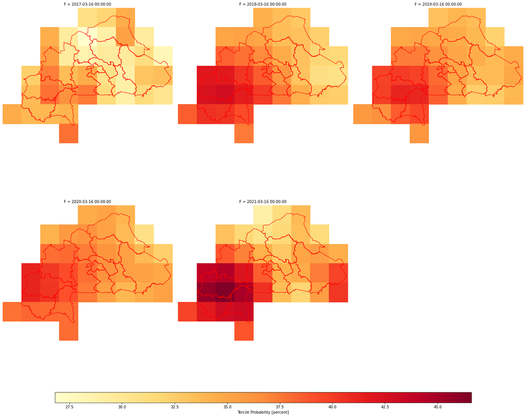

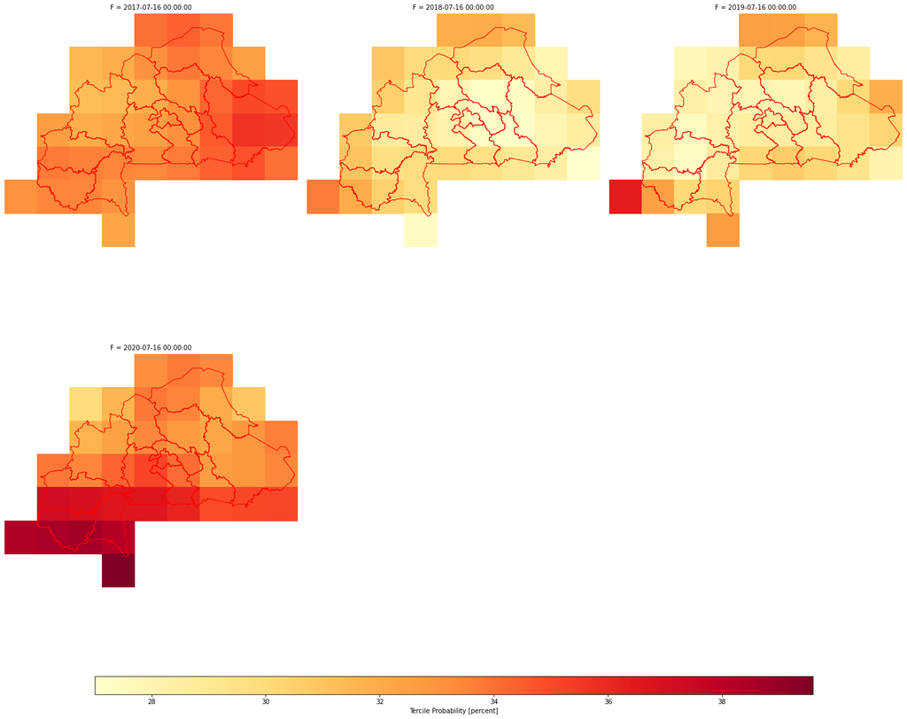

we select the region of interest, shown below

```
(-6.056338028169014, 2.056338028169014, 8.945454545454545, 15.054545454545455)
```

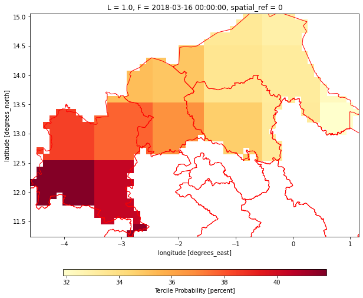

And compute the statistics over this region, see a subset below

```python
stats_region[(stats_region.C==0)&(stats_region.L==1)&(stats_region.F.dt.month==3)]
```

|  | C | F | L | mean_cell | min_cell | max_cell | std_cell | 10perc_cell | quantile | month |
| --- | --- | --- | --- | --- | --- | --- | --- | --- | --- | --- |
| 0 | 0 | 2017-03-16 | 1.0 | 31.495157 | 26.800935 | 37.261748 | 3.252510 | 35.567945 | 0.9 | 3 |
| 48 | 0 | 2018-03-16 | 1.0 | 35.963292 | 31.873917 | 41.878787 | 2.903000 | 40.363758 | 0.9 | 3 |
| 96 | 0 | 2019-03-16 | 1.0 | 35.965496 | 32.200421 | 41.015097 | 2.129139 | 39.771293 | 0.9 | 3 |
| 144 | 0 | 2020-03-16 | 1.0 | 36.544649 | 30.768471 | 41.184953 | 2.025928 | 39.318485 | 0.9 | 3 |
| 192 | 0 | 2021-03-16 | 1.0 | 35.403506 | 30.697005 | 44.935194 | 4.227613 | 42.255976 | 0.9 | 3 |

Below the distribution of probability values is shown per month. This only includes the values for the below-average tercile, with a leadtime of 1. It should be noted that since we only have data from Mar 2017, these distributions contain maximum 5 values. From the distribution, it can be seen that a probability of 50% has never been reached since Mar 2017.

```
More specifically we are interested in March and July. <br> The maximum values across all cells for the March forecasts has been 44.94%, and for the July forecasts 36.66%
             This would mean that if we would take the max cell as aggregation method, the threshold of 40 for March would have been reached 4 times  in 2018, 2019, 2020, 2021.
             For July the threshold of 50 would have been reached 0 times.
```

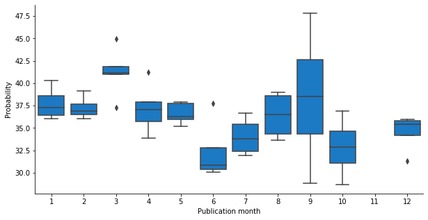

To check if these below 50% and below 40% probabilities depend on the part of the country, we also compute the maximum values in the whole country across all years. While the values can be slightly higher in other regions, the 50% threshold is never reached. We can see that the maximum probabilities in other regions are a bit higher, while still never reaching the 50% threshold.

[output not shown]

While taking the max cell is the most extreme method of aggregation, we have many other possiblities. Such as looking at the mean, or at a percentage of cells. For the July forecast we also wouldn't trigger, since we already didn't trigger with the max methodology.

```
For March, when using the mean method aggregation, the trigger would have been met 0 times.
             When requiring 10% of cells to be above 40% this would be 2 times in 2018, 2021.
```